# Fama-French Three-Factor Model Replication

Size and Book-to-Market Portfolio Analysis

Author

Asset Pricing Research

Published

May 24, 2026

# 1 Introduction

This report replicates the **Fama-French three-factor (FF3) model** using daily data from Kenneth French’s data library. The six test portfolios are formed on the two-way sort of **size** (market equity, ME) and **book-to-market ratio** (BM), yielding 2 × 3 = 6 portfolios.

| Symbol | Description |
| --- | --- |
| MKT | Excess market return ($R_m - R_f$) |
| SMB | Small-Minus-Big (size factor) |
| HML | High-Minus-Low (value factor) |

The regression specification for portfolio $i$ is:

$$R_{i,t} - R_{f,t} = \alpha_i
+ \beta_i^{\text{MKT}}\,\text{MKT}_t
+ \beta_i^{\text{SMB}}\,\text{SMB}_t
+ \beta_i^{\text{HML}}\,\text{HML}_t + \varepsilon_{i,t}$$

Standard errors are **Newey-West** adjusted (5 lags).

## 1.1 Sample Information

| Item | Value |
| --- | --- |
| Start date | July 01, 1926 |
| End date | March 31, 2026 |
| Daily observations | 26,212 |
| Data source | Kenneth R. French Data Library (daily) |

# 2 Factor Summary Statistics

Table 1: Descriptive statistics for Fama-French daily factors (% per day).

|  | MKT | SMB | HML |
| --- | --- | --- | --- |
| Mean | 0.0307 | 0.0039 | 0.0152 |
| Std Dev | 1.0780 | 0.5941 | 0.6265 |
| Min | -17.4400 | -11.6000 | -6.0200 |
| Max | 15.6700 | 8.1900 | 8.8200 |
| Skewness | -0.1585 | -0.6135 | 0.6302 |
| Kurtosis | 16.1435 | 20.1919 | 14.2476 |
| t-stat | 4.6041 | 1.0521 | 3.9171 |

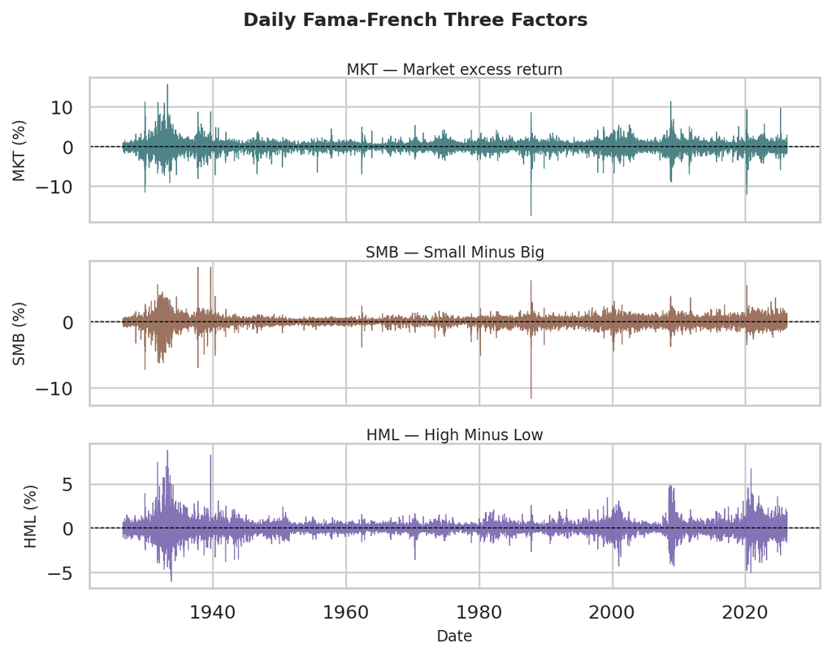

Figure 1: Daily time series of the three Fama-French factors.

# 3 Portfolio Excess Return Statistics

Table 2: Descriptive statistics for 6 portfolio daily excess returns (% per day).

|  | Mean | Std Dev | Min | Max | Sharpe (ann.) | t-stat |
| --- | --- | --- | --- | --- | --- | --- |
| SMALL LoBM | 0.0279 | 1.2739 | -14.07 | 17.49 | 0.3482 | 3.5509 |
| ME1 BM2 | 0.0405 | 1.1685 | -14.08 | 18.38 | 0.5504 | 5.6130 |
| SMALL HiBM | 0.0474 | 1.2968 | -16.02 | 26.70 | 0.5802 | 5.9170 |
| BIG LoBM | 0.0311 | 1.1100 | -18.13 | 13.64 | 0.4452 | 4.5405 |
| ME2 BM2 | 0.0311 | 1.1117 | -18.77 | 23.57 | 0.4440 | 4.5285 |
| BIG HiBM | 0.0420 | 1.4045 | -17.91 | 22.06 | 0.4745 | 4.8389 |

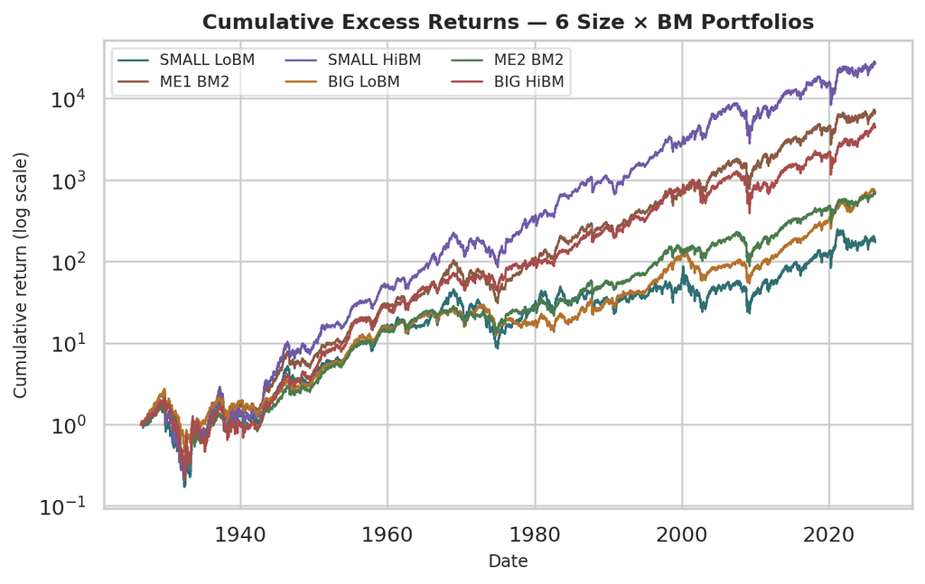

Figure 2: Cumulative excess returns of the six size-BM portfolios (log scale).

# 4 Correlation Matrix

Table 3: Pearson correlation matrix of factors and portfolio excess returns.

|  | MKT | SMB | HML | SMALL LoBM | ME1 BM2 | SMALL HiBM | BIG LoBM | ME2 BM2 | BIG HiBM |
| --- | --- | --- | --- | --- | --- | --- | --- | --- | --- |
| MKT | 1.000 | -0.133 | 0.140 | 0.849 | 0.869 | 0.836 | 0.981 | 0.960 | 0.899 |
| SMB | -0.133 | 1.000 | -0.066 | 0.340 | 0.304 | 0.290 | -0.174 | -0.185 | -0.156 |
| HML | 0.140 | -0.066 | 1.000 | 0.011 | 0.266 | 0.444 | 0.008 | 0.280 | 0.498 |
| SMALL LoBM | 0.849 | 0.340 | 0.011 | 1.000 | 0.913 | 0.861 | 0.813 | 0.789 | 0.763 |
| ME1 BM2 | 0.869 | 0.304 | 0.266 | 0.913 | 1.000 | 0.942 | 0.811 | 0.844 | 0.837 |
| SMALL HiBM | 0.836 | 0.290 | 0.444 | 0.861 | 0.942 | 1.000 | 0.764 | 0.833 | 0.858 |
| BIG LoBM | 0.981 | -0.174 | 0.008 | 0.813 | 0.811 | 0.764 | 1.000 | 0.907 | 0.829 |
| ME2 BM2 | 0.960 | -0.185 | 0.280 | 0.789 | 0.844 | 0.833 | 0.907 | 1.000 | 0.914 |
| BIG HiBM | 0.899 | -0.156 | 0.498 | 0.763 | 0.837 | 0.858 | 0.829 | 0.914 | 1.000 |

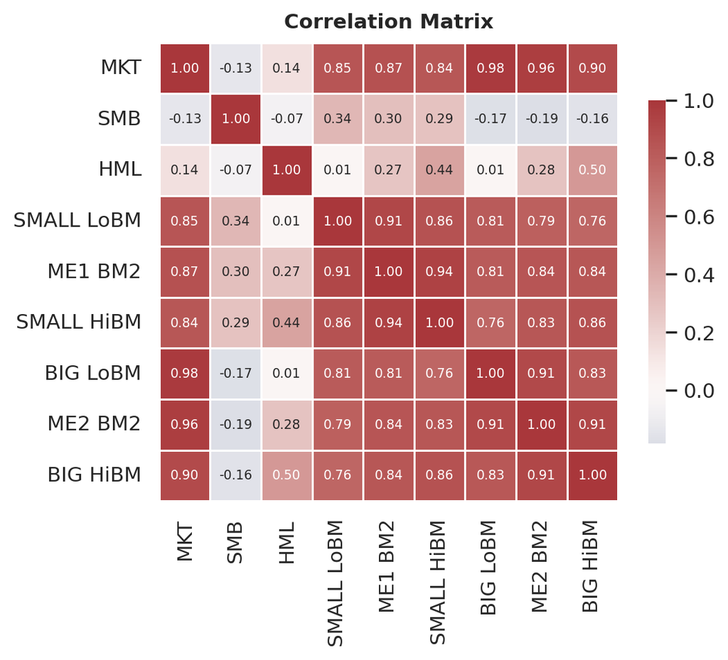

Figure 3: Heatmap of the correlation matrix.

# 5 Fama-French Three-Factor Regressions

## 5.1 Regression Coefficients

Table 4: FF3 regression results. t-statistics in parentheses (Newey-West, 5 lags). *** p<0.01, ** p<0.05, * p<0.10.

| Portfolio | α | (t-α) | β MKT | (t-MKT) | β SMB | (t-SMB) | β HML | (t-HML) | R² | N |
| --- | --- | --- | --- | --- | --- | --- | --- | --- | --- | --- |
| SMALL LoBM | -0.0065*** | (-3.61) | 1.0898*** | (184.10) | 0.9788*** | (106.40) | -0.1798*** | (-19.44) | 0.9374 | 26,212 |
| ME1 BM2 | 0.0024* | (1.93) | 0.9789*** | (303.97) | 0.8549*** | (159.57) | 0.3145*** | (54.00) | 0.9619 | 26,212 |
| SMALL HiBM | 0.0016* | (1.83) | 1.0141*** | (333.00) | 0.9278*** | (202.74) | 0.7327*** | (137.23) | 0.9853 | 26,212 |
| BIG LoBM | 0.0038*** | (4.04) | 1.0227*** | (352.69) | -0.0961*** | (-21.53) | -0.2394*** | (-62.28) | 0.9825 | 26,212 |
| ME2 BM2 | -0.0019 | (-1.21) | 0.9616*** | (174.23) | -0.0970*** | (-13.86) | 0.2589*** | (30.03) | 0.9453 | 26,212 |
| BIG HiBM | -0.0044** | (-2.43) | 1.0984*** | (194.00) | -0.0451*** | (-4.96) | 0.8481*** | (86.79) | 0.9489 | 26,212 |

## 5.2 Alpha Estimates

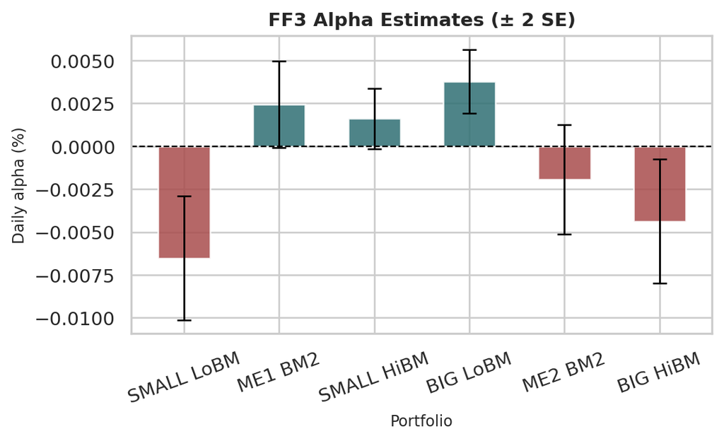

Figure 4: FF3 daily alpha estimates with ±2 SE error bars.

## 5.3 Factor Loadings Comparison

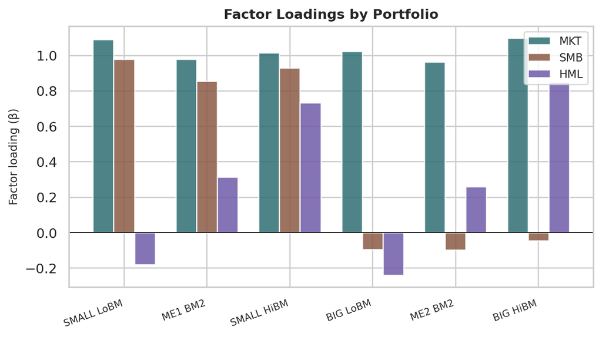

Figure 5: Factor loadings (β) for MKT, SMB, and HML across the six portfolios.

# 6 Model Fit — R²

Table 5: Goodness-of-fit summary for each portfolio regression.

| Portfolio | R² | Adj. R² | N |
| --- | --- | --- | --- |
| SMALL LoBM | 0.9374 | 0.9374 | 26,212 |
| ME1 BM2 | 0.9619 | 0.9619 | 26,212 |
| SMALL HiBM | 0.9853 | 0.9853 | 26,212 |
| BIG LoBM | 0.9825 | 0.9825 | 26,212 |
| ME2 BM2 | 0.9453 | 0.9453 | 26,212 |
| BIG HiBM | 0.9489 | 0.9489 | 26,212 |

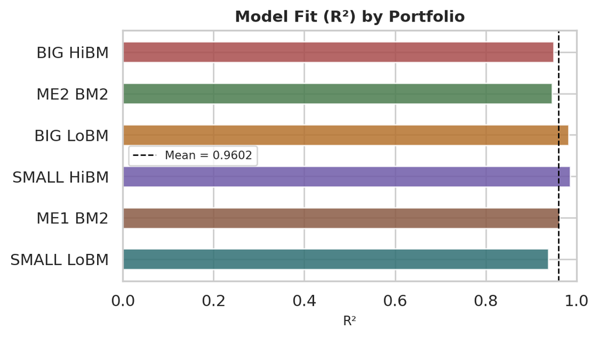

Figure 6: R² by portfolio. Dashed line shows the cross-portfolio mean.

# 7 Interpretation

Table 6

| Finding | Value |
| --- | --- |
| Average R² | 0.9602 |
| Highest \|alpha\| | SMALL LoBM (-0.0065% / day) |
| Best-fit portfolio | SMALL HiBM (R² = 0.9853) |
| SMB: Small vs Big LoBM | 0.979 vs -0.096 |
| HML: Small HiBM vs Big LoBM | 0.733 vs -0.239 |

**Market factor (MKT):** All portfolios load positively and significantly near 1.0, consistent with well-diversified equity exposure.

**Size factor (SMB):** Small-cap portfolios carry large positive SMB loadings; big-cap portfolios have near-zero or negative loadings — confirming size separation.

**Value factor (HML):** High-BM portfolios carry large positive HML loadings; low-BM portfolios carry negative loadings — the classic value vs growth split.

# 8 Saved Output Files

| File | Description |
| --- | --- |
| `table_factor_statistics.csv` | Factor descriptive stats |
| `table_portfolio_excess_return_statistics.csv` | Portfolio excess-return stats |
| `table_correlation_matrix.csv` | Full correlation matrix |
| `table_ff3_regression_results.csv` | Regression coefficients |
| `figure_factor_timeseries.png` | Factor time-series chart |
| `figure_cumulative_excess_returns.png` | Cumulative-return chart |
| `figure_alpha_bar.png` | Alpha bar chart with error bars |
| `figure_factor_loadings.png` | Factor loadings bar chart |
| `figure_correlation_heatmap.png` | Correlation heatmap |
| `figure_r2.png` | R-squared bar chart |

# 9 References

- Fama, E. F., & French, K. R. (1993). Common risk factors in the returns on stocks and bonds. *Journal of Financial Economics*, 33(1), 3–56.
- French, K. R. Data Library. https://mba.tuck.dartmouth.edu/pages/faculty/ken.french/data_library.html
- Newey, W. K., & West, K. D. (1987). A simple, positive semi-definite, heteroskedasticity and autocorrelation consistent covariance matrix. *Econometrica*, 55(3), 703–708.